# Aproximação de funções pelo método dos mínimos quadrados

O método dos mínimos quadrados é útil quando queremos aproximar uma função $f(x)$ por uma outra função $g(x)$, seja porque $f$ não tem expressão analítica conhecida, seja por ser de difícil tratamento ou manipulação.

No **caso discreto**, $f(x)$ é conhecida apenas num conjunto finito de pontos e no **caso contínuo**, $f(x)$ tem expressão conhecida. A função $g(x)$ pode ser uma combinação linear de funções polinomiais, exponenciais, logarítmicas, trigonométricas, etc.

Generalizando, podemos escrever a função $g(x)$ como segue:

$$ g(x) = a_1g_1(x)+a_1g_1(x)+...+a_ng_n(x)$$

Para encontrar a função $g(x)$ que melhor "se ajusta" aos $n$ pontos conhecidos de uma função $f(x)$ devemos buscar minimizar os desvios, ou erros $e(x_i) = f(x_i)-g(x_i)$, $i=1,...,m$. No método dos mínimos quadrados fazemos isso minimizando a soma

$$ E = \sum_{i=1}^{m} [e(x_i)]^2= \sum_{i=1}^{m} [f(x_i)-g(x_i)]^2 $$

Note que, deferentemente do que aproximar $f$ por interpolação, com mínimos quadrados, função $g(x)$ não necessariamente precisa passar pelos pontos mas sim se ajustar a eles.

Se $f$ for conhecida, podemos buscar pela função $g$ que minimize o erro

$$ E = \int_a^b [e(x)]^2 dx = \int_a^b [f(x)-g(x)]^2 dx$$

## Caso discreto

Inicialmente vamos supor que queremos ajustar uma reta $g(x) = a1x+a2$ aos pontos $(x_i, f(x_i))$, $i=1,...,m$, como é mostrado na figura abaixo

[figure not shown]

Então, buscamos os coeficientes $a_1$ e $a_2$ que definem a reta que melhor se ajusta aos pontos, ou seja, os coeficientes que minimizam a função

$$ E(a_1, a_2)= \sum_{i=1}^{m} [f(x_i)-g(x_i)]^2 $$

Do cálculo infinitesimal, sabemos que se a função $ E(a_1, a_2)$ possui um ponto de mínimo, suas derivadas parciais nesse ponto devem ser numas, ou seja

$$ \frac{\partial E}{\partial a_1} = 0 \,\,\,\,\, \frac{\partial E}{\partial a_2} = 0$$

Derivando $ E(a_1, a_2)$ em relação a $a_1$ e $a_2$ obtemos

$$ \frac{\partial E}{\partial a_1} = 2 \left[a_1\sum_{i=1}^{m} x_i^2 + a_2\sum_{i=1}^{m} x_i \right] - 2 \left[\sum_{i=1}^{m} f(x_i)x_i \right] =0$$

e

$$ \frac{\partial E}{\partial a_2} = 2 \left[a_1\sum_{i=1}^{m} x_i + ma_2 - \sum_{i=1}^{m} f(x_i)\right] =0$$

As equações obtidas nos permitem encontrar $a_1$ e $a_2$ por meio da resolução do sistema linear

$$ \begin{cases} \left(\sum_{i=1}^{m} x_i^2\right)a_ 1 + \left(\sum_{i=1}^{m} x_i\right)a_ 2 = \sum_{i=1}^{m} f(x_i)x_i \\ \left(\sum_{i=1}^{m} x_i\right)a_ 1 + ma_ 2 = \sum_{i=1}^{m} f(x_i) \end{cases} $$

ou

$$\left[\begin{array}{cc} \sum_{i=1}^{m} x_i^2 & \sum_{i=1}^{m} x_i \\ \sum_{i=1}^{m} x_i & m \end{array} \right] \left[\begin{array}{c} a_1 \\ a_2 \end{array} \right] = \left[\begin{array}{c} \sum_{i=1}^{m} f(x_i)x_i \\ \sum_{i=1}^{m} f(x_i) \end{array} \right] $$

## Exemplo

Ajuste uma reta à função $f(x)$, tabelada como segue $$\begin{array}{cccccc} x_i &0 &1 &2 &3 &4\\ f(x_i) &0.98 &-3.01 &-6.99 &-11.01 &-15 \end{array} $$

### Resolução

```
[-3.996  0.986]
```

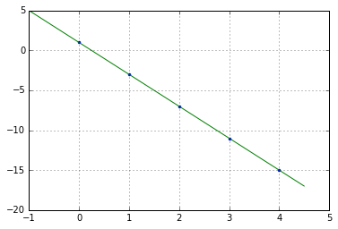

```python
% matplotlib inline
import numpy as np
from scipy.linalg import solve
import matplotlib.pyplot as plt

X = np.array([0, 1, 2, 3, 4])
Y = np.array([0.98, -3.01, -6.99, -11.01, -15.0])

# Calcula os elementos das marizes
a11 = np.sum(X**2)
a12 = np.sum(X)
a22 = len(X)
b1 = np.sum(X * Y)
b2 = np.sum(Y)

# Monta e resolve o sistema
A = np.array([[a11, a12], [a12, a22]])

B = np.array([b1,b2])

a = solve(A, B)
print (a)

# define a funcao g(x) para plotar
g = lambda x: a[0]*x+a[1]

# cria pontos (x, y) da reta
Xr = np.arange(-1, 5, 0.5)

# Plota os pontos e a reta
plt.plot(X, Y, ".", Xr, g(Xr), "-")
plt.grid()
plt.show()
```

Para aproximar a função f(x) por um polinômio de grau 2, usamos a seguinte forma geral para $g(x)$

$$ g(x)=a_1g_1(x) + a_2g_2(x) + a_3g_3(x) = a_1x^2 + a_2x + a_3$$

com $g_1(x) = x^2$, $g_2(x) = x$ e $g_3(x) = 1$.

Generalizando o procedimento, podemos determinar os coeficientes $a_1,a_2,...,a_n$ da função$ g(x) = a_1g_1(x)+a_1g_1(x)+...+a_ng_n(x)$ resolvendo o sistema linear formado pelas equações

$$ \frac{\partial E}{\partial a_1} = 0, \,\, \frac{\partial E}{\partial a_2} = 0, ..., \,\, \frac{\partial E}{\partial a_n} = 0$$

ou seja,

$$ \begin{cases} \left(\sum_{i=1}^{m} g_1(x_i)g_1(x_i)\right)a_1 + \left(\sum_{i=1}^{m} g_1(x_i)g_2(x_i)\right)a_2+...+\left(\sum_{i=1}^{m} g_1(x_i)g_n(x_i)\right)a_n = \sum_{i=1}^{m} f(x_i)g_1(x_i) \\ \left(\sum_{i=1}^{m} g_2(x_i)g_1(x_i)\right)a_1 + \left(\sum_{i=1}^{m} g_2(x_i)g_2(x_i)\right)a_2+...+\left(\sum_{i=1}^{m} g_2(x_i)g_n(x_i)\right)a_n = \sum_{i=1}^{m} f(x_i)g_2(x_i) \\ \vdots\\ \left(\sum_{i=1}^{m} g_n(x_i)g_1(x_i)\right)a_1 + \left(\sum_{i=1}^{m} g_n(x_i)g_2(x_i)\right)a_2+...+\left(\sum_{i=1}^{m} g_n(x_i)g_n(x_i)\right)a_n = \sum_{i=1}^{m} f(x_i)g_n(x_i) \\ \end{cases} $$

### Exemplo

p184

```
[ 5.08982143  0.05189286 -1.14371429]
```

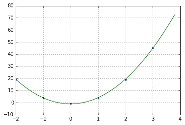

```python
% matplotlib inline
import numpy as np
from scipy.linalg import solve
import matplotlib.pyplot as plt

X = np.array([-2., -1., 0, 1., 2., 3.])
Y = np.array([19.01, 3.99, -1.00, 4.01, 18.99, 45.00])

# Calcula os elementos das marizes
A11 = np.sum(X**4)
A12 = np.sum(X**3)
A13 = np.sum(X**2)
A23 = np.sum(X)
A33 = len(X)
B1 = np.sum(X**2*Y)
B2 = np.sum(X*Y)
B3 = np.sum(Y)

# Monta e resolve o sistema
A = np.array([[A11,A12, A13],[A12, A13, A23], [A13, A23, A33]])
B = np.array([B1,B2,B3])
a = solve(A, B)
print (a)

# define a funcao g(x) para plotar
g = lambda x: a[0]*x*x+a[1]*x+a[2]

# cria pontos (x, y) da reta
Xr = np.arange(X[0], X[-1]+1, 0.2)
Yr = []
for x in Xr:
    Yr.append(g(x))

# Plota os pontos e a reta
plt.plot(X, Y, ".", Xr, Yr, "-")
plt.grid()
plt.show()
```

### Exemplo

p186

```
[-0.5  0.   0.5  1.   1.5  2.   2.5  3.   3.5  4.   4.5]
71.5 2.0 5.0
36.75 3.5
[ 0.5  0.5]
```

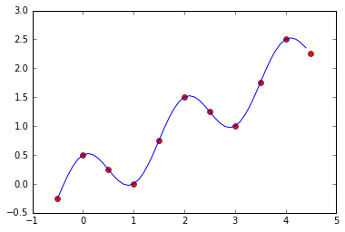

```python
% matplotlib inline
import numpy as np
from scipy.linalg import solve
import matplotlib.pyplot as plt

X = np.array([-0.5, 0.0, 0.5, 1.0, 1.5, 2.0, 2.5, 3.0, 3.5, 4.0, 4.5])
Y = np.array([-0.25, 0.5, 0.25, 0.0, 0.75, 1.5, 1.25, 1.00, 1.75, 2.5, 2.25])

# Calcula os elementos das marizes
g1 = lambda X: X
g2 = lambda X: np.cos(np.pi*X)

print (g1(X))
a11 = np.sum(np.multiply(g1(X),g1(X)))
a12 = np.sum(np.multiply(g1(X),g2(X)))
a21 = a12
a22 = np.sum(np.multiply(g2(X),g2(X)))

print (a11, a12, a22)

b1 = np.sum(np.multiply(Y,g1(X)))
b2 = np.sum(np.multiply(Y,g2(X)))

print (b1,b2)


# Monta e resolve o sistema
A = np.array([[a11, a12],
              [a21, a22]])

B = np.array([b1,b2])

a = solve(A, B)
print (a)

# define a funcao g(x) para plotar
g = lambda X: a[0]*g1(X)+a[1]*g2(X)

# cria pontos (x, y) da reta
Xr = np.arange(X[0], X[-1], 0.1)
Yr = g(Xr)

# Plota os pontos e a reta
plt.plot(X, Y, "ro", Xr, Yr, "-")
plt.show()
```

No caso da função $f(x)$ ser conhecida, podemos ajustar a função $g(x)$ de modo a minimizar

$$ E = \int_a^b [e(x)]^2 dx = \int_a^b [f(x)-g(x)]^2 dx$$

o que leva a necessidade de resolução do sistema linear

$$\left[\begin{array}{cccc} \langle g_1,g_1 \rangle &\langle g_1,g_2 \rangle &... &\langle g_1,g_n \rangle\\ \langle g_2,g_1 \rangle &\langle g_2,g_2 \rangle &... &\langle g_2,g_n \rangle\\ \vdots \\ \langle g_n,g_1 \rangle &\langle g_n,g_2 \rangle &... &\langle g_n,g_n \rangle\\ \end{array} \right] \left[\begin{array}{c} a_1 \\ a_2 \\ \vdots \\ a_n \end{array} \right] = \left[\begin{array}{c} \langle f,g_1 \rangle \\ \langle f,g_2 \rangle \\ \vdots \\ \langle f,g_n \rangle \\ \end{array} \right] $$

Com $\langle f,g \rangle$ sendo o produto escalar entre as funções $f$ e $g$, definido como

$$ \langle f,g \rangle = \int_a^b f(x)g(x)dx$$